# PSL: Polynomial Regression

## Load Data and Packages

For linear regression, we utilize two primary packages:

- **statsmodels**, when we require detailed statistical outputs such as t-tests and p-values.
- **sklearn**, when our focus is solely on prediction.

Additionally, we've incorporated a function to generate orthogonal polynomials, mirroring the functionality of R's `poly` function. We also include a `summarize` function sourced from the ISLP package. This function processes a fitted statsmodels object to return the usual coefficient estimates, their standard errors, the usual test statistics and P-values.

```python
import numpy as np
import pandas as pd
import matplotlib.pyplot as plt

import statsmodels.api as sm
from sklearn.linear_model import LinearRegression
```

```python
# copy from ISLP package
def summarize(results,
              conf_int=False):
    """
       https://github.com/intro-stat-learning/ISLP/blob/main/ISLP/models/__init__.py
    """
    tab = results.summary().tables[1]
    results_table = pd.read_html(tab.as_html(),
                                 index_col=0,
                                 header=0)[0]
    if not conf_int:
        columns = ['coef', 'std err', 't','P>|t|']
        return results_table[results_table.columns[:-2]]
    return results_table

# converted from R's poly()
# ref: https://stackoverflow.com/questions/39031172/how-poly-generates-orthogonal-polynomials-how-to-understand-the-coefs-ret
# compute orthogonal polynomials
def poly(x, degree):
    x_mean = x.mean(axis=0)
    x = x - x_mean
    Z = np.power.outer(x, np.arange(0, degree+1))

    # orthogonalize
    x = x.reshape(-1, 1)
    qr = np.linalg.qr(Z, mode='complete')
    z = np.zeros_like(Z)
    np.fill_diagonal(z, np.diag(qr[1]))
    Z = qr[0] @ z
    norm2 = (Z ** 2.0).sum(axis=0)
    alpha = (x * Z ** 2.0).sum(axis=0) / norm2 + x_mean
    Z = Z / np.sqrt(norm2)
    norm2 = np.insert(norm2, 0, 1.0, axis=0)

    return Z[:, 1:], alpha[:-1], norm2


def poly_predict(x_new, degree, alpha, norm2):
    n = x_new.shape[0]
    Z = np.ones((n, degree + 1))
    Z[:, 1] = x_new - alpha[0]
    for i in range(1, degree):
        Z[:, i + 1] = (x_new - alpha[i]) * Z[:, i]
        Z[:, i + 1] -= (norm2[i + 1] / norm2[i]) * Z[:, i - 1]

    Z = Z / np.sqrt(norm2[1:])

    return Z[:, 1:]
```

Load the Wage data (from ISLR, Chapter 7), which contains income and demographic information for males who reside in the central Atlantic region of the United States. We will fit `wage` (in thousands of dollars) as a function of `age`.

```python
url = "https://liangfgithub.github.io/Data/Wage.csv"
Wage = pd.read_csv(url)
Wage.describe()
```

```python
age = Wage['age'].to_numpy()
wage = Wage['wage']
```

## Fit a Polynomial Regression Model

Two Methods to specify the design matrix for polynomial regression:

- Method 1: Manually specify each term of the polynomial. For example, a cubic model would include terms like x, x^2, x^3.
- Method 2: Using the poly function. This is a more compact and efficient way, especially when d is large. For example, `poly(x,3)` directly creates a cubic polynomial model.

When you use the poly function, like `poly(age, 3)`, you’re not directly getting age, age^2, age^3. Instead, you get three orthogonalized (and standardized) polynomial variables.

For example, `poly(age, 3)` returns an n-by-3 matrix:

```python
X1 = np.power.outer(age, np.arange(1, 4))
M1 = sm.OLS(wage, sm.add_constant(X1)).fit()
summarize(M1)
```

|  | coef | std err | t | P>\|t\| |
| --- | --- | --- | --- | --- |
| const | -75.2439 | 22.184 | -3.392 | 0.001 |
| x1 | 10.1900 | 1.605 | 6.348 | 0.000 |
| x2 | -0.1680 | 0.037 | -4.559 | 0.000 |
| x3 | 0.0008 | 0.000 | 3.143 | 0.002 |

```python
X2, alpha, norm2 = poly(age, 3)
M2 = sm.OLS(wage, sm.add_constant(X2)).fit()
summarize(M2)
```

|  | coef | std err | t | P>\|t\| |
| --- | --- | --- | --- | --- |
| const | 111.7036 | 0.729 | 153.211 | 0.000 |
| x1 | 447.0679 | 39.933 | 11.195 | 0.000 |
| x2 | -478.3158 | 39.933 | -11.978 | 0.000 |
| x3 | 125.5217 | 39.933 | 3.143 | 0.002 |

```python
print(X2.shape)
print(X2.mean(axis=0))
print(np.round(X2.T @ X2, 4))
```

```
(3000, 3)
[-2.46330734e-19  9.47195158e-19 -2.37078875e-19]
[[ 1. -0. -0.]
 [-0.  1. -0.]
 [-0. -0.  1.]]
```

## Prediction

Method 1 and Method 2 would produce different coefficients, but the fitted values (predictions) remain the same.

```python
fit1 = LinearRegression().fit(X1, wage)
fit1.intercept_, fit1.coef_
```

```
(-75.24391422432832,
 array([ 1.01899915e+01, -1.68028587e-01,  8.49452197e-04]))
```

```python
fit2 = LinearRegression().fit(X2, wage)
fit2.intercept_, fit2.coef_
```

```
(111.70360820174345, array([ 447.06785276, -478.31580585,  125.52168603]))
```

```python
age_new = np.array([82])
age_new = poly_predict(age_new, 3, alpha, norm2)
fit2.predict(age_new)
```

```
array([98.87192947])
```

```python
tmp = np.power.outer(82, np.arange(1, 4))
fit1.intercept_ + tmp @ fit1.coef_
```

```
98.87192946555125
```

Note that although the coefficients in `fit1` and `fit2` are different, the t-value and p-value for the last predictor remain identical. Why is this the case?

In the context of linear regression, the t-test for a variable gauges its conditional contribution. In both `fit1` and `fit2`, the sole unique contribution of the cubic term of `age` comes only from the last variable, irrespective of whether it’s represented as “age^3” or “poly(age, 3)”. Thus, the p-value for the last variable in both models, which measures the unique contribution of the cubic term of age, isolated from the influences of other variables, stays the same.

Thus, if your primary concern is gauging the significance of the coefficient linked with the highest order term, the choice of design matrix becomes inconsequential. Whether you utilize the direct design matrix or the orthogonal polynomial design matrix, the significance of the highest order term remains consistent.

This insight becomes particularly valuable when employing forward and backward selection methods to determine the optimal d.

## Fitted Curve

`fit1` and `fit2` should return an identical fitted curve.

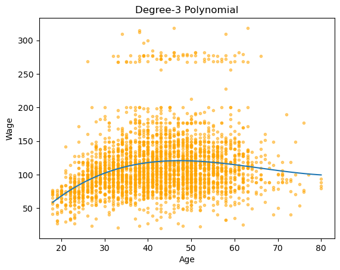

```python
age_grid = np.arange(age.min(), age.max() + 1)
age_grid_poly = poly_predict(age_grid, 3, alpha, norm2)
y_grid = fit.predict(age_grid_poly)

plt.plot(age_grid, y_grid)
plt.scatter(age, wage, marker='.', alpha=0.5, c='orange')
plt.title("Degree-3 Polynomial")
plt.xlabel("Age")
plt.ylabel("Wage")
```

Next, we explore how to select the polynomial degree d using forward and backward approaches.

## Forward Selection

- Starting with a linear model, we introduce a quadratic term and assess the significance of this newly added variable. Given its significant p-value, we retain the quadratic term.
- Proceeding, we introduce a cubic term. Once again, its significance necessitates its inclusion.
- On adding the quartic term (where d=4), the p-value hovers around 5%, placing it at the edge of our significance threshold. If sticking to a strict 5% cutoff, we would revert to the cubic model, as the quartic term fails to meet the significance criterion.
- Hence the forward selection concludes with a preference for the cubic regression model.

```python
d = 2
tmp, alpha, norm2 = poly(age, d)
summarize(sm.OLS(wage, sm.add_constant(tmp)).fit())
```

|  | coef | std err | t | P>\|t\| |
| --- | --- | --- | --- | --- |
| const | 111.7036 | 0.730 | 152.985 | 0.0 |
| x1 | 447.0679 | 39.993 | 11.179 | 0.0 |
| x2 | -478.3158 | 39.993 | -11.960 | 0.0 |

```python
d = 3
tmp, alpha, norm2 = poly(age, d)
summarize(sm.OLS(wage, sm.add_constant(tmp)).fit())
```

|  | coef | std err | t | P>\|t\| |
| --- | --- | --- | --- | --- |
| const | 111.7036 | 0.729 | 153.211 | 0.000 |
| x1 | 447.0679 | 39.933 | 11.195 | 0.000 |
| x2 | -478.3158 | 39.933 | -11.978 | 0.000 |
| x3 | 125.5217 | 39.933 | 3.143 | 0.002 |

```python
d = 4
tmp, alpha, norm2 = poly(age, d)
summarize(sm.OLS(wage, sm.add_constant(tmp)).fit())
```

|  | coef | std err | t | P>\|t\| |
| --- | --- | --- | --- | --- |
| const | 111.7036 | 0.729 | 153.283 | 0.000 |
| x1 | 447.0679 | 39.915 | 11.201 | 0.000 |
| x2 | -478.3158 | 39.915 | -11.983 | 0.000 |
| x3 | 125.5217 | 39.915 | 3.145 | 0.002 |
| x4 | -77.9112 | 39.915 | -1.952 | 0.051 |

## Backward Selection

```python
d = 6
tmp, alpha, norm2 = poly(age, d)
summarize(sm.OLS(wage, sm.add_constant(tmp)).fit())
```

|  | coef | std err | t | P>\|t\| |
| --- | --- | --- | --- | --- |
| const | 111.7036 | 0.729 | 153.316 | 0.000 |
| x1 | 447.0679 | 39.906 | 11.203 | 0.000 |
| x2 | -478.3158 | 39.906 | -11.986 | 0.000 |
| x3 | 125.5217 | 39.906 | 3.145 | 0.002 |
| x4 | -77.9112 | 39.906 | -1.952 | 0.051 |
| x5 | -35.8129 | 39.906 | -0.897 | 0.370 |
| x6 | 62.7077 | 39.906 | 1.571 | 0.116 |

```python
d = 5
tmp, alpha, norm2 = poly(age, d)
summarize(sm.OLS(wage, sm.add_constant(tmp)).fit())
```

|  | coef | std err | t | P>\|t\| |
| --- | --- | --- | --- | --- |
| const | 111.7036 | 0.729 | 153.278 | 0.000 |
| x1 | 447.0679 | 39.916 | 11.200 | 0.000 |
| x2 | -478.3158 | 39.916 | -11.983 | 0.000 |
| x3 | 125.5217 | 39.916 | 3.145 | 0.002 |
| x4 | -77.9112 | 39.916 | -1.952 | 0.051 |
| x5 | -35.8129 | 39.916 | -0.897 | 0.370 |

```python
d = 4
tmp, alpha, norm2 = poly(age, d)
summarize(sm.OLS(wage, sm.add_constant(tmp)).fit())
```

|  | coef | std err | t | P>\|t\| |
| --- | --- | --- | --- | --- |
| const | 111.7036 | 0.729 | 153.283 | 0.000 |
| x1 | 447.0679 | 39.915 | 11.201 | 0.000 |
| x2 | -478.3158 | 39.915 | -11.983 | 0.000 |
| x3 | 125.5217 | 39.915 | 3.145 | 0.002 |
| x4 | -77.9112 | 39.915 | -1.952 | 0.051 |

```python
d = 3
tmp, alpha, norm2 = poly(age, d)
summarize(sm.OLS(wage, sm.add_constant(tmp)).fit())
```

|  | coef | std err | t | P>\|t\| |
| --- | --- | --- | --- | --- |
| const | 111.7036 | 0.729 | 153.211 | 0.000 |
| x1 | 447.0679 | 39.933 | 11.195 | 0.000 |
| x2 | -478.3158 | 39.933 | -11.978 | 0.000 |
| x3 | 125.5217 | 39.933 | 3.143 | 0.002 |